# ECN 301E LAB #2

Let's start with setting the global path:

```stata
global path "E:\Users\Buğra\Google Drive\TA\ECN 301E\Fall '18\Labs" /* change to whatever makes you happy */
```

Import the [dataset](https://drive.google.com/open?id=1m_QlnocbDaEVHH-OCy-u_-fMjuUJhBhq):

```stata
use "$path\Lab 2\data-exercise-02-nls.dta", clear
```

Tell STATA to describe the dataset so we can see the variables and their labels:

```stata
describe
```

```
Contains data from E:\Users\Buğra\Google Drive\TA\ECN 301E\Fall '18\Labs\Lab 2\data-exercise-02-nls.dta
  obs:           935
 vars:            15                          10 Oct 2005 15:03
 size:        56,100
---------------------------------------------------------------------------------------------------------------------------------------------------------------------------------------------------------------------------------------------------------------
              storage   display    value
variable name   type    format     label      variable label
---------------------------------------------------------------------------------------------------------------------------------------------------------------------------------------------------------------------------------------------------------------
wage            float   %9.0g                 monthly earnings
hours           float   %9.0g                 average weekly hours
IQ              float   %9.0g                 IQ score
educ            float   %9.0g                 years education
exper           float   %9.0g                 years of work experience
tenure          float   %9.0g                 years with current employer
age             float   %9.0g                 age
married         float   %9.0g                 =1 if married
black           float   %9.0g                 =1 if black
south           float   %9.0g                 =1 if south
urban           float   %9.0g
sibs            float   %9.0g                 number of siblings
brthord         float   %9.0g                 birth order
meduc           float   %9.0g                 mother's education
feduc           float   %9.0g                 father's education
---------------------------------------------------------------------------------------------------------------------------------------------------------------------------------------------------------------------------------------------------------------
Sorted by:
```

Now let's answer the questions:

**1) How many individuals are there in the dataset?**

```stata
sum
```

```
    Variable |        Obs        Mean    Std. Dev.       Min        Max
-------------+---------------------------------------------------------
        wage |        935    957.9455    404.3608        115       3078
       hours |        935    43.92941    7.224256         20         80
          IQ |        935    101.2824    15.05264         50        145
        educ |        935    13.46845    2.196654          9         18
       exper |        935    11.56364    4.374586          1         23
-------------+---------------------------------------------------------
      tenure |        935    7.234225    5.075206          0         22
         age |        935    33.08021    3.107803         28         38
     married |        935    .8930481    .3092174          0          1
       black |        935    .1283422    .3346495          0          1
       south |        935    .3411765    .4743582          0          1
-------------+---------------------------------------------------------
       urban |        935    .7176471    .4503851          0          1
        sibs |        935    2.941176    2.306254          0         14
     brthord |        852    2.276995    1.595613          1         10
       meduc |        857    10.68261    2.849756          0         18
       feduc |        741    10.21727      3.3007          0         18
```

The first column of the table above gives us the number of observations (individuals in this case). There are $935$ individuals.

**2) What is the age range?**

```stata
sum age
```

```
    Variable |        Obs        Mean    Std. Dev.       Min        Max
-------------+---------------------------------------------------------
         age |        935    33.08021    3.107803         28         38
```

Here we can see that the minimum age value is $28$ and the maximum age value is $38$. So the age range is $38-28=10$.

**3) What proportion is black?**

```stata
count if black==1
```

```
  120
```

This number is the number of blacks in the sample. Since we know that the sample size is $935$, we can calculate the proportion of blacks by

```stata
disp 120/935
```

```
.12834225
```

Remember: You can use the `display` or `disp` command to have Stata act as a calculator.

**OR** since the variable **black** is a dummy variable, the mean of it is equal to the proportion of blacks (Why?).

```stata
mean(black)
```

```
Mean estimation                   Number of obs   =        935

--------------------------------------------------------------
             |       Mean   Std. Err.     [95% Conf. Interval]
-------------+------------------------------------------------
       black |   .1283422   .0109442      .1068642    .1498203
--------------------------------------------------------------
```

**4) What are the mean and median monthly earnings?**

```stata
sum wage, detail
```

```
                      monthly earnings
-------------------------------------------------------------
      Percentiles      Smallest
 1%          325            115
 5%          433            200
10%          500            233       Obs                 935
25%          668            260       Sum of Wgt.         935

50%          905                      Mean           957.9455
                        Largest       Std. Dev.      404.3608
75%         1160           2668
90%         1444           2771       Variance       163507.7
95%         1699           3078       Skewness       1.199259
99%         2308           3078       Kurtosis       5.696661
```

The mean monthly earnings is $957.9455$

The median monthly earnings is $905$ (50th percentile)

**5) How do earnings vary by education, work experience, marital status, urban/rural areas, South/North, birth order, number of siblings?**

```stata
tabulate educ, summarize(wage)
```

```
      years |     Summary of monthly earnings
  education |        Mean   Std. Dev.       Freq.
------------+------------------------------------
          9 |       774.3   239.78928          10
         10 |   719.48571   265.86743          35
         11 |   818.81395   326.26627          43
         12 |   862.67176   324.38961         393
         13 |   946.12941   450.31473          85
         14 |   990.01299   411.41423          77
         15 |   1098.9111   485.67113          45
         16 |   1108.7133   390.49857         150
         17 |     1191.45   468.99221          40
         18 |   1200.8246    531.7439          57
------------+------------------------------------
      Total |   957.94545   404.36082         935
```

```stata
tabulate exper, summarize(wage)
```

```
   years of |
       work |     Summary of monthly earnings
 experience |        Mean   Std. Dev.       Freq.
------------+------------------------------------
          1 |     1004.75   516.19783          12
          3 |        1375           0           1
          4 |   880.72414   350.06304          29
          5 |   819.86667   342.92482          30
          6 |   911.85417   427.59331          48
          7 |    968.7963   377.93153          54
          8 |   1009.3889   434.57058          72
          9 |   948.54878   404.70441          82
         10 |   1028.5972    428.8704          72
         11 |   936.35955   428.52899          89
         12 |   1015.2308   575.67403          65
         13 |   968.37097   354.09577          62
         14 |   987.48148   408.35268          54
         15 |      925.35    312.6319          60
         16 |   961.14706   384.54052          68
         17 |    951.5283    323.8974          53
         18 |   918.46667   311.86909          30
         19 |   963.78261   276.14159          23
         20 |   772.92857   223.20272          14
         21 |       942.5   563.36174          12
         22 |        1323   480.05937           3
         23 |         845   148.49242           2
------------+------------------------------------
      Total |   957.94545   404.36082         935
```

```stata
tabulate married, summarize(wage)
```

```
      =1 if |     Summary of monthly earnings
    married |        Mean   Std. Dev.       Freq.
------------+------------------------------------
          0 |      798.44   343.20955         100
          1 |    977.0479    407.0803         835
------------+------------------------------------
      Total |   957.94545   404.36082         935
```

```stata
tabulate urban, summarize(wage)
```

```
            |     Summary of monthly earnings
      urban |        Mean   Std. Dev.       Freq.
------------+------------------------------------
          0 |   830.10985   351.32612         264
          1 |   1008.2414   412.92978         671
------------+------------------------------------
      Total |   957.94545   404.36082         935
```

```stata
tabulate south, summarize(wage)
```

```
            |     Summary of monthly earnings
=1 if south |        Mean   Std. Dev.       Freq.
------------+------------------------------------
          0 |   1004.3003   392.17958         616
          1 |    868.4326   413.02136         319
------------+------------------------------------
      Total |   957.94545   404.36082         935
```

```stata
tabulate brthord, summarize(wage)
```

```
            |     Summary of monthly earnings
birth order |        Mean   Std. Dev.       Freq.
------------+------------------------------------
          1 |   1026.9855   417.71912         346
          2 |   955.39749   407.35719         239
          3 |   981.88095   420.85843         126
          4 |   886.24561   313.77262          57
          5 |       875.8    359.9749          35
          6 |   772.42857   293.27353          28
          7 |       798.4   309.96889          10
          8 |       781.8   174.87195           5
          9 |         947   70.547856           3
         10 |   758.66667   239.36861           3
------------+------------------------------------
      Total |   970.89319   403.84158         852
```

```stata
tabulate sibs, summarize(wage)
```

```
  number of |     Summary of monthly earnings
   siblings |        Mean   Std. Dev.       Freq.
------------+------------------------------------
          0 |   1025.5735   439.06044          68
          1 |   1024.4346   427.84949         214
          2 |   989.94949   426.15813         198
          3 |   982.81143   386.30276         175
          4 |   856.86957   359.54811          92
          5 |   864.59722   347.31257          72
          6 |         861   387.22596          39
          7 |   877.35294   380.15602          34
          8 |   815.35714    350.1858          14
          9 |       799.3    329.6928          10
         10 |   677.44444   121.04143           9
         11 |      871.75   316.41573           4
         12 |         818           0           1
         13 |         836   320.34513           3
         14 |       949.5   119.50105           2
------------+------------------------------------
      Total |   957.94545   404.36082         935
```

**6) What is the relationship between earnings and IQ, between being black and living in the South, between mother’s and father’s education, between education and experience?**

```stata
corr wage IQ
```

```
(obs=935)

             |     wage       IQ
-------------+------------------
        wage |   1.0000
          IQ |   0.3091   1.0000
```

```stata
corr black south
```

```
(obs=935)

             |    black    south
-------------+------------------
       black |   1.0000
       south |   0.2365   1.0000
```

```stata
corr meduc feduc
```

```
(obs=722)

             |    meduc    feduc
-------------+------------------
       meduc |   1.0000
       feduc |   0.5765   1.0000
```

```stata
corr educ exper
```

```
(obs=935)

             |     educ    exper
-------------+------------------
        educ |   1.0000
       exper |  -0.4556   1.0000
```

**7) Run a simple regression by regression wage on education. Interpret the coefficient estimates, R squared, Root MSE.**

```stata
reg wage educ
```

```
      Source |       SS           df       MS      Number of obs   =       935
-------------+----------------------------------   F(1, 933)       =    111.79
       Model |  16340644.5         1  16340644.5   Prob > F        =    0.0000
    Residual |   136375524       933  146168.836   R-squared       =    0.1070
-------------+----------------------------------   Adj R-squared   =    0.1060
       Total |   152716168       934  163507.675   Root MSE        =    382.32

------------------------------------------------------------------------------
        wage |      Coef.   Std. Err.      t    P>|t|     [95% Conf. Interval]
-------------+----------------------------------------------------------------
        educ |   60.21428   5.694982    10.57   0.000     49.03783    71.39074
       _cons |   146.9524   77.71496     1.89   0.059     -5.56393    299.4688
------------------------------------------------------------------------------
```

1 year increase in the years of education increases the monthly earnings by $60.21428$ dollars.

Monthly earning of an individual with no education is $146.9524$.

**8) Draw a graph which includes fitted values against the actual values of the regression in the previous question.**

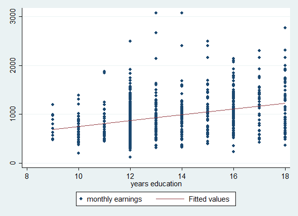

```stata
scatter wage educ || lfit wage educ
```

## Do-file

The `do-file` for this exercise can be found [here](https://drive.google.com/open?id=18IS6ZahgRSyixR-7PhU9XyPMIqarO1iV).